# Modeling the Impact of a Household Carbon Tax in Argentina: A Microsimulation Exercise

##### Outputs

**Percent change increase in energy expenditure as a proportion of income**

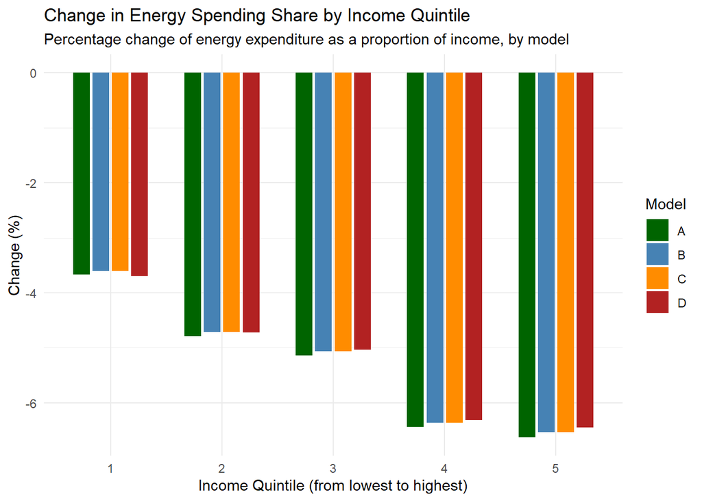

```r
# Precompute the C‐series pct_change
pctD <- household_tax_III_D %>%
  mutate(
    income_after_rebate = ingtoth + rebate
  ) %>%
  group_by(quintile) %>%
  summarise(
    share_before = sum(total_spent_energy,  na.rm = TRUE) / sum(ingtoth, na.rm = TRUE),
    share_after  = sum(total_spent_energy2, na.rm = TRUE) / sum(income_after_rebate, na.rm = TRUE)
  ) %>%
  mutate(
    pct_change = (share_after / share_before - 1) * 100,
    pp_change = (share_after - share_before)
  )

pct_change_III_D <- bind_rows(
  pct_change_III_C,
  pctD %>% mutate(model = "D")
)

energy_share_change_model_III_D <- ggplot(
    pct_change_III_D,
    aes(
      x    = factor(quintile),
      y    = pct_change,
      fill = model
    )
  ) +
  geom_bar(
    stat     = "identity",
    position = position_dodge(width = 0.7),
    width    = 0.6
  ) +
  scale_fill_manual(
    values = c(A = "darkgreen", B = "steelblue", C = "darkorange", D = "firebrick"),
    name   = "Model"
  ) +
  labs(
    title    = "Change in Energy Spending Share by Income Quintile",
    subtitle = "Percentage change of energy expenditure as a proportion of income, by model",
    x        = "Income Quintile (from lowest to highest)",
    y        = "Change (%)"
  ) +
  scale_x_discrete(labels = as.character(1:5)) +
  theme_minimal()

print(energy_share_change_model_III_D)
```

**Contribution to gov income revenue**

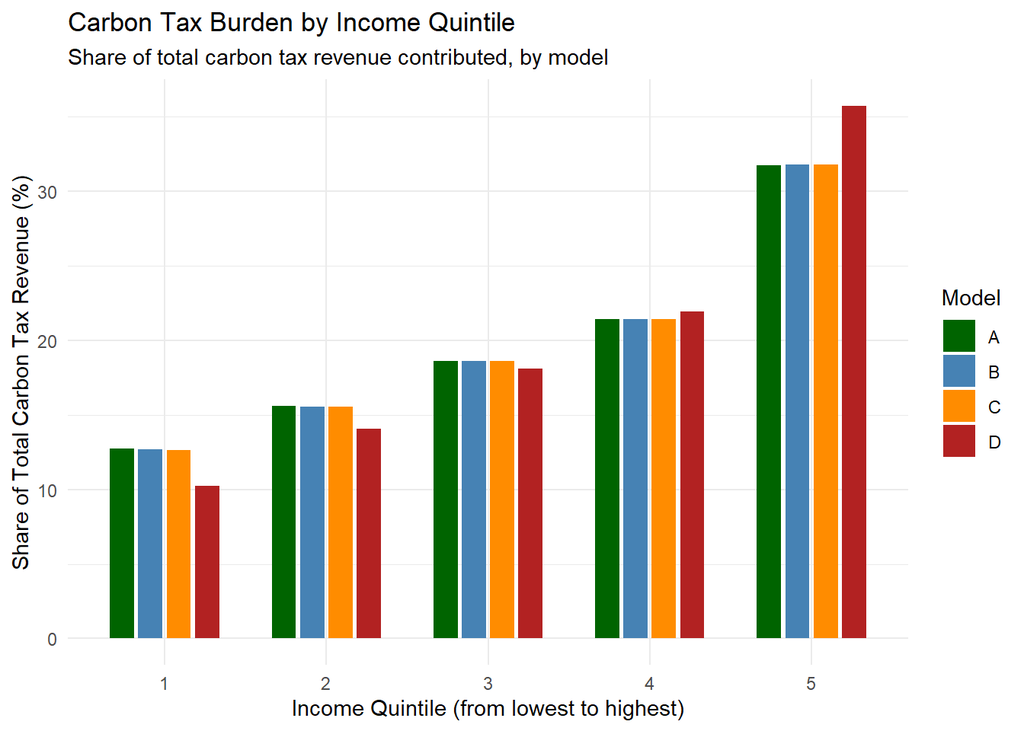

```r
# Summarise D
quintile_contributions_III_D <- household_tax_III_D %>%
  group_by(quintile) %>%
  summarise(
    total_tax_paid    = sum(total_carbon_tax2, na.rm = TRUE),
    total_income      = sum(ingtoth, na.rm = TRUE),
    total_net_income  = sum(net_income3, na.rm = TRUE),
    total_rebate      = sum(rebate, na.rm = TRUE)
  ) %>%
  mutate(
    percent_contribution    = 100 * ((total_tax_paid - total_rebate)  / net_revenue_III_D),
    percent_change_income   = 100 * ((total_net_income - total_income) / total_income),
    model = "D"
  ) %>%
  select(quintile, percent_contribution, percent_change_income, model)

quintile_contributions_III_D <- bind_rows(
  quintile_contributions_III_C,
  quintile_contributions_III_D
)

carbon_tax_burden_model_III_D <- ggplot(
    quintile_contributions_III_D,
    aes(
      x    = factor(quintile),
      y    = percent_contribution,
      fill = model
    )
  ) +
  geom_bar(
    stat     = "identity",
    position = position_dodge(width = 0.7),
    width    = 0.6
  ) +
  scale_fill_manual(
    values = c(A = "darkgreen", B = "steelblue", C = "darkorange", D = "firebrick"),
    name   = "Model"
  ) +
  labs(
    title    = "Carbon Tax Burden by Income Quintile",
    subtitle = "Share of total carbon tax revenue contributed, by model",
    x        = "Income Quintile (from lowest to highest)",
    y        = "Share of Total Carbon Tax Revenue (%)"
  ) +
  scale_x_discrete(labels = as.character(1:5)) +
  theme_minimal()

print(carbon_tax_burden_model_III_D)
```

**Household percent change in net income after tax**

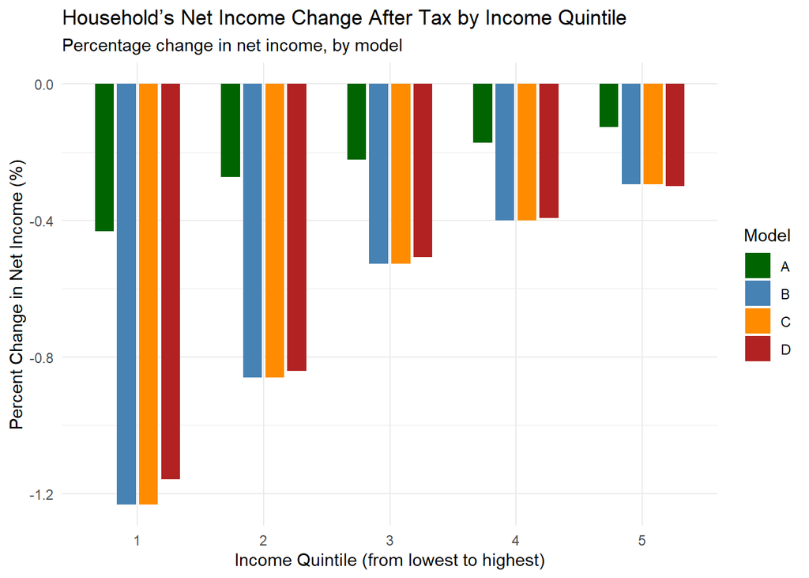

```r
net_income_model_III_D <- ggplot(
    quintile_contributions_III_D,
    aes(x = factor(quintile),
        y = percent_change_income,
        fill = model)
  ) +
  geom_bar(
    stat = "identity",
    position = position_dodge(width = 0.7),
    width = 0.6
  ) +
  labs(
    title    = "Household’s Net Income Change After Tax by Income Quintile",
    subtitle = "Percentage change in net income, by model",
    x        = "Income Quintile (from lowest to highest)",
    y        = "Percent Change in Net Income (%)",
    fill     = "Model"
  ) +
  scale_fill_manual(
    values = c(A = "darkgreen", B = "steelblue", C = "darkorange", D = "firebrick")
  ) +
  theme_minimal()

print(net_income_model_III_D)
```

**Geographic Analysis**

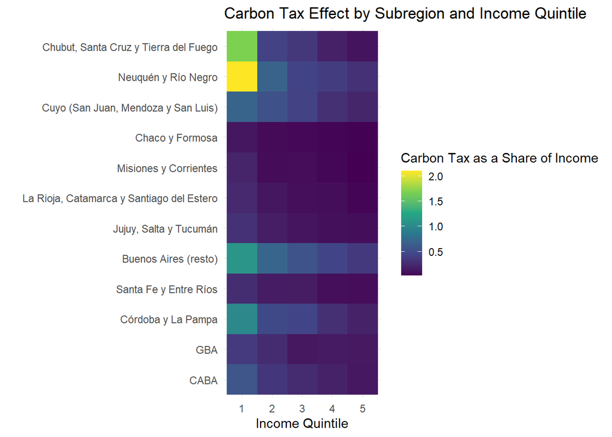

```r
# Step 1: Bring subregion info to household level
household_with_subregion_III_D <- carbon_tax_III_D %>%
  select(id, subregion) %>%
  distinct() %>%
  left_join(household_tax_III_D, by = "id")

# Step 2: Group by subregion and quintile
subregion_quintile_model_III_D <- household_with_subregion_III_D %>%
  group_by(subregion, quintile) %>%
  filter(ingtoth > 0) %>%
  summarise(
    avg_tax_pct = mean((total_carbon_tax2 / ingtoth) * 100, na.rm = TRUE),
    .groups = "drop"
  )

# Step 3: Plot
subregion_model_III_D <- ggplot(subregion_quintile_model_III_D, aes(x = factor(quintile), y = subregion, fill = avg_tax_pct)) +
  geom_tile() +
  scale_y_discrete(labels = subregion_labels) +
  scale_fill_viridis_c() +
  labs(
    title = "Carbon Tax Effect by Subregion and Income Quintile",
    x = "Income Quintile",
    y = "",
    fill = "Carbon Tax as a Share of Income"
  ) +
  theme_minimal()

print(subregion_model_III_D)
```

#### Scenario E

A bolder tax increase (+30%) across all polluting fuels to drive stronger carbon cuts, paired with a large targeted rebate (40% of revenues) for the poorest 40% to protect equity.

##### Model

```r
elasticity <- -0.76   # Change for different scenarios
rebate_mode <- "by_quintile"  # Options: "none", "uniform", "by_quintile"
rebate_target_quintiles <- c(1, 2)  # Only used if rebate_mode == "by_quintile"
gas_increment <- 0.3 # Change ratio to increase / decrease tax on gas articles
fossil_increment <- 0.3 # Change ratio to increase / decrease tax on fossil articles
firewood_increment <- 0.3
rebate_share <- 0.4  # Ratio of revenue that goes into rebate (can't be more than 1)


# Function that applies differentiated tax rates by type of item/energy
calculate_carbon_tax <- function(cantidad, articulo,
                                 fossil = fossil_increment, #ratio of increment
                                 gas = gas_increment,
                                 wood = firewood_increment) #ratio of increment
{
  # Tax rates based on type of energy
  tax_rates <- case_when(
    # Highly polluting fossil fuels
    articulo == "A0453101" ~ 3.54* (1 + fossil),  # Kerosene
    articulo == "A0453103" ~ 3.02* (1 + fossil),  # Other fuels

    # Gas (medium emissions)
    articulo == "A0452101" ~ 2.12 * (1 + gas),  # Bottled gas in cylinders
    articulo == "A0452102" ~ 2.12 * (1 + gas),  # Bulk gas
    articulo == "A0452103" ~ 2.61 * (1 + gas),  # Natural gas - primary residence
    articulo == "A0452104" ~ 2.12 * (1 + gas),  # Gas in tubes
    articulo == "A0452105" ~ 2.61 * (1 + gas),  # Natural gas - secondary residence

    # Electricity (varies by energy matrix, but directly less polluting)
    articulo == "A0451101" ~ 0,  # Electricity - primary residence
    articulo == "A0451102" ~ 0,  # Electricity - secondary residence
    articulo == "A0451103" ~ 0,  # Electricity expenses for another residence

    # Firewood and coal (may be renewable or not depending on the source)
    articulo == "A0453102" ~ 5.6 * (1 + wood),  # Firewood and coal

    # Others
    TRUE ~ 0                     # Standard rate
  )

  # Calculate tax
  tax <- cantidad * tax_rates
  return(tax)
}
```

```r
# Step 1: calculate tax by energy type
carbon_tax_III_E <- carbon_tax %>%
  mutate(
    carbon_tax_item = map2_dbl(
      .x = cantidad,
      .y = articulo,
      .f = calculate_carbon_tax
    ),
    #original price paid
    price = monto/cantidad,
    #per unit markup after tax
    tax_per_unit = carbon_tax_item/cantidad,
    # Effective tax rate
    tax_rate = tax_per_unit / price,

    # Apply elasticity adjustment to quantity
    cantidad2 = cantidad * (1 + tax_rate) ^ elasticity,
    price2 = price * (1 + tax_rate),
    monto2 = cantidad2 * price2,
    carbon_tax_item2 = cantidad2 * tax_per_unit
  )
```

```r
# Step 2: Total tax paid by household
household_tax_III_E <- carbon_tax_III_E %>%
  group_by(id) %>%
  summarise(
    total_carbon_tax = sum(carbon_tax_item, na.rm = TRUE),
    total_carbon_tax2 = sum(carbon_tax_item2, na.rm = TRUE),
    ingtoth = first(ingtoth), # Take the first income by id (it is the same for each id)
    total_spent_energy = sum(monto, na.rm = TRUE),
    total_spent_energy2 = sum(monto2, na.rm = TRUE)
  ) %>%
  mutate(
    net_income = ingtoth - total_carbon_tax,
    net_income2 = ingtoth - total_carbon_tax2
  )
```

```r
# Step 3: Calculate quintiles based on income
household_tax_III_E <- household_tax_III_E %>%
  mutate(
    quintile= ntile(ingtoth, 5)
  )

## Step 3.1: Add rebate if any

total_revenue_III_E <- sum(household_tax_III_E$total_carbon_tax, na.rm = TRUE)
total_revenue_III_E2 <- sum(household_tax_III_E$total_carbon_tax2, na.rm = TRUE)
rebate_pool_III_E <- total_revenue_III_E2 * rebate_share
net_revenue_III_E <- total_revenue_III_E2 - rebate_pool_III_E

household_tax_III_E <- household_tax_III_E %>%
  mutate(
    rebate = case_when(
      rebate_mode == "uniform" ~ rebate_pool_III_E / n(),
      rebate_mode == "by_quintile" & quintile %in% rebate_target_quintiles ~
        rebate_pool_III_E / sum(quintile %in% rebate_target_quintiles),
      rebate_mode %in% c("by_quintile", "none") ~ 0,
      TRUE ~ 0
    ),
    net_income3 = net_income + rebate  # updated post-rebate income
  )
```

```r
# Step 4: Analyzing income
quintile_analysis_III_E <- household_tax_III_E %>%
  group_by(quintile) %>%
  summarise(
    avg_total_income = mean(ingtoth, na.rm = TRUE),
    avg_net_income = mean(net_income, na.rm = TRUE),
    avg_net_income2 = mean(net_income3, na.rm = TRUE),
    avg_tax = mean(total_carbon_tax, na.rm = TRUE),
    avg_tax2 = mean(total_carbon_tax2, na.rm = TRUE),
    avg_tax_burden = mean(total_carbon_tax/ingtoth * 100, na.rm = TRUE),
    avg_tax_burden2 = mean(total_carbon_tax2/ingtoth * 100, na.rm = TRUE)
  )

carbon_tax_with_quintile_III_E <- carbon_tax_III_E %>%
  left_join(
    household_tax_III_E %>% select(id, quintile, total_carbon_tax),
    by = "id"
  )
```

##### Outputs

**Percent change increase in energy expenditure as a proportion of income**

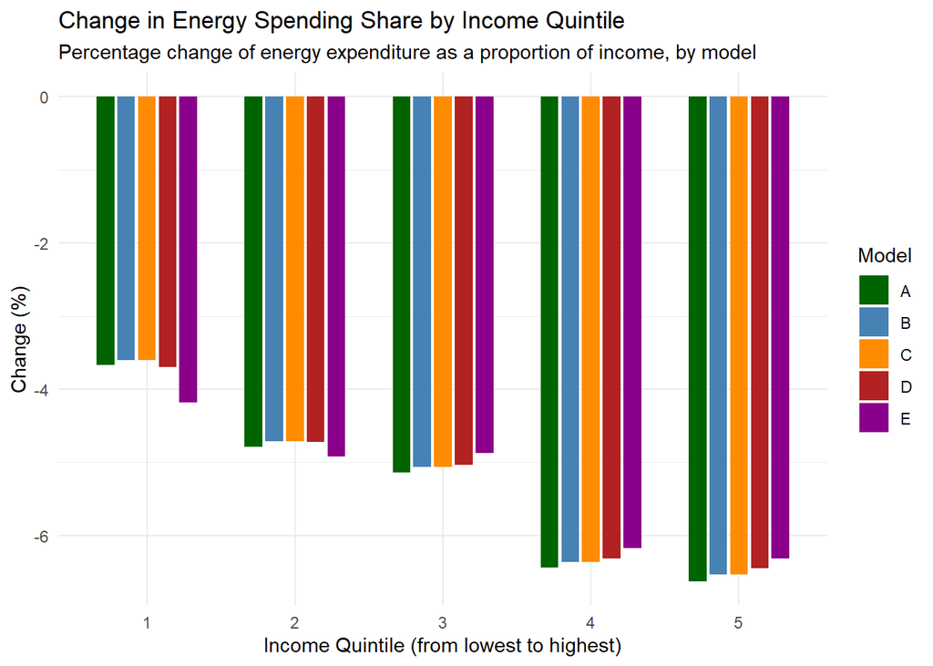

```r
# Precompute the C‐series pct_change
pctE <- household_tax_III_E %>%
  mutate(
    income_after_rebate = ingtoth + rebate
  ) %>%
  group_by(quintile) %>%
  summarise(
    share_before = sum(total_spent_energy,  na.rm = TRUE) / sum(ingtoth, na.rm = TRUE),
    share_after  = sum(total_spent_energy2, na.rm = TRUE) / sum(income_after_rebate, na.rm = TRUE)
  ) %>%
  mutate(
    pct_change = (share_after / share_before - 1) * 100,
    pp_change = (share_after - share_before)
  )

pct_change_III_E <- bind_rows(
  pct_change_III_D,
  pctE %>% mutate(model = "E")
)

energy_share_change_model_III_E <- ggplot(
    pct_change_III_E,
    aes(
      x    = factor(quintile),
      y    = pct_change,
      fill = model
    )
  ) +
  geom_bar(
    stat     = "identity",
    position = position_dodge(width = 0.7),
    width    = 0.6
  ) +
  scale_fill_manual(
    values = c(A = "darkgreen", B = "steelblue", C = "darkorange", D = "firebrick", E = "darkmagenta"),
    name   = "Model"
  ) +
  labs(
    title    = "Change in Energy Spending Share by Income Quintile",
    subtitle = "Percentage change of energy expenditure as a proportion of income, by model",
    x        = "Income Quintile (from lowest to highest)",
    y        = "Change (%)"
  ) +
  scale_x_discrete(labels = as.character(1:5)) +
  theme_minimal()

print(energy_share_change_model_III_E)
```

**Contribution to gov income revenue**

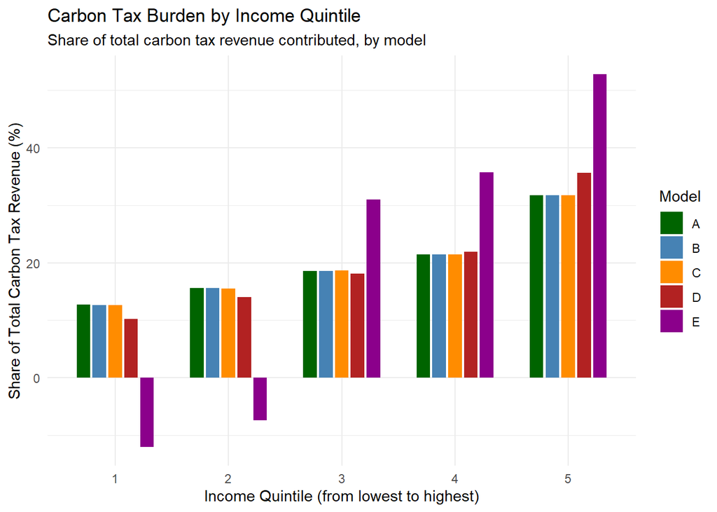

```r
# Summarise D
quintile_contributions_III_E <- household_tax_III_E %>%
  group_by(quintile) %>%
  summarise(
    total_tax_paid    = sum(total_carbon_tax2, na.rm = TRUE),
    total_income      = sum(ingtoth, na.rm = TRUE),
    total_net_income  = sum(net_income3, na.rm = TRUE),
    total_rebate      = sum(rebate, na.rm = TRUE)
  ) %>%
  mutate(
    percent_contribution    = 100 * ((total_tax_paid - total_rebate)  / net_revenue_III_E),
    percent_change_income   = 100 * ((total_net_income - total_income) / total_income),
    model = "E"
  ) %>%
  select(quintile, percent_contribution, percent_change_income, model)

quintile_contributions_III_E <- bind_rows(
  quintile_contributions_III_D,
  quintile_contributions_III_E
)

carbon_tax_burden_model_III_E <- ggplot(
    quintile_contributions_III_E,
    aes(
      x    = factor(quintile),
      y    = percent_contribution,
      fill = model
    )
  ) +
  geom_bar(
    stat     = "identity",
    position = position_dodge(width = 0.7),
    width    = 0.6
  ) +
  scale_fill_manual(
    values = c(A = "darkgreen", B = "steelblue", C = "darkorange", D = "firebrick", E = "darkmagenta"),
    name   = "Model"
  ) +
  labs(
    title    = "Carbon Tax Burden by Income Quintile",
    subtitle = "Share of total carbon tax revenue contributed, by model",
    x        = "Income Quintile (from lowest to highest)",
    y        = "Share of Total Carbon Tax Revenue (%)"
  ) +
  scale_x_discrete(labels = as.character(1:5)) +
  theme_minimal()

print(carbon_tax_burden_model_III_E)
```

**Household percent change in net income after tax**

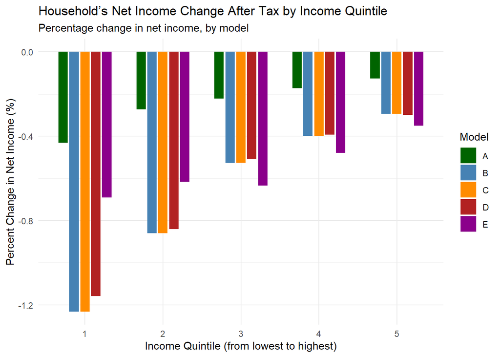

```r
net_income_model_III_E <- ggplot(
    quintile_contributions_III_E,
    aes(x = factor(quintile),
        y = percent_change_income,
        fill = model)
  ) +
  geom_bar(
    stat = "identity",
    position = position_dodge(width = 0.7),
    width = 0.6
  ) +
  labs(
    title    = "Household’s Net Income Change After Tax by Income Quintile",
    subtitle = "Percentage change in net income, by model",
    x        = "Income Quintile (from lowest to highest)",
    y        = "Percent Change in Net Income (%)",
    fill     = "Model"
  ) +
  scale_fill_manual(
    values = c(A = "darkgreen", B = "steelblue", C = "darkorange", D = "firebrick", E = "darkmagenta")
  ) +
  theme_minimal()

print(net_income_model_III_E)
```

**Geographic Analysis**

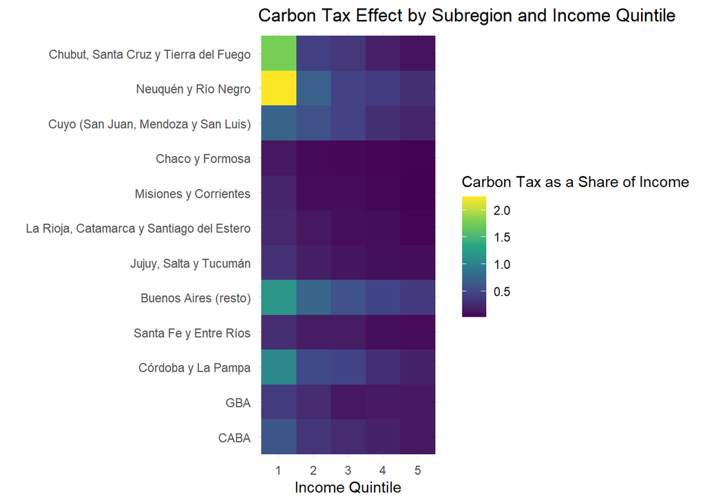

```r
# Step 1: Bring subregion info to household level
household_with_subregion_III_E <- carbon_tax_III_E %>%
  select(id, subregion) %>%
  distinct() %>%
  left_join(household_tax_III_E, by = "id")

# Step 2: Group by subregion and quintile
subregion_quintile_model_III_E <- household_with_subregion_III_E %>%
  group_by(subregion, quintile) %>%
  filter(ingtoth > 0) %>%
  summarise(
    avg_tax_pct = mean((total_carbon_tax2 / ingtoth) * 100, na.rm = TRUE),
    .groups = "drop"
  )

# Step 3: Plot
subregion_model_III_E <- ggplot(subregion_quintile_model_III_E, aes(x = factor(quintile), y = subregion, fill = avg_tax_pct)) +
  geom_tile() +
  scale_y_discrete(labels = subregion_labels) +
  scale_fill_viridis_c() +
  labs(
    title = "Carbon Tax Effect by Subregion and Income Quintile",
    x = "Income Quintile",
    y = "",
    fill = "Carbon Tax as a Share of Income"
  ) +
  theme_minimal()

print(subregion_model_III_E)
```

#### Laffer curve

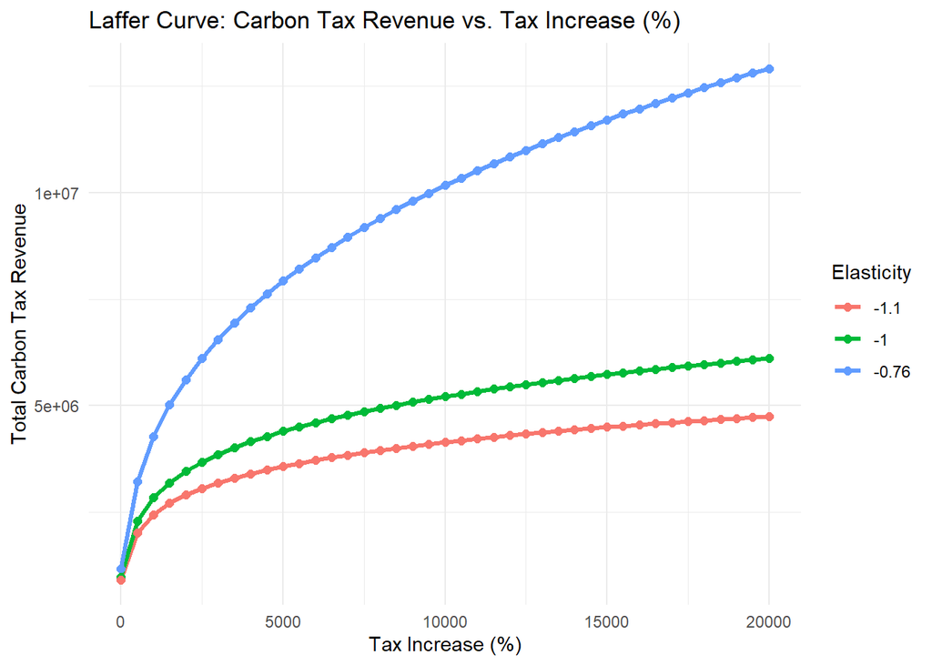

```r
library(furrr)
library(future)

# Set up parallel processing
plan(multisession, workers = 7)

# Define elasticities and tax multipliers
elasticities <- c(-0.76, -1, -1.1)
tax_multipliers <- seq(0, 200, by = 5)

# Grid of combinations
simulation_grid <- expand.grid(elasticity = elasticities, tax_multiplier = tax_multipliers)

# Run simulations
laffer_data <- simulation_grid %>%
  mutate(
    total_revenue = future_map2_dbl(elasticity, tax_multiplier, function(e_val, multiplier) {

      carbon_tax_temp <- carbon_tax %>%
        mutate(
          carbon_tax_item = map2_dbl(
            cantidad, articulo,
            ~ calculate_carbon_tax(.x, .y,
                                   fossil = multiplier,
                                   gas = multiplier,
                                   wood = multiplier)
          ),
          price = monto / cantidad,
          tax_per_unit = carbon_tax_item / cantidad,
          tax_rate = tax_per_unit / price,

          cantidad2 = cantidad * (1 + tax_rate) ^ e_val,
          price2 = price * (1 + tax_rate),
          carbon_tax_item2 = cantidad2 * tax_per_unit
        )

      # Total Revenue
      carbon_tax_temp %>%
        group_by(id) %>%
        summarise(tax_paid = sum(carbon_tax_item2, na.rm = TRUE), .groups = "drop") %>%
        summarise(total = sum(tax_paid, na.rm = TRUE)) %>%
        pull(total)
    })
  )

ggplot(laffer_data, aes(x = tax_multiplier * 100, y = total_revenue, color = factor(elasticity))) +
  geom_line(size = 1.2) +
  geom_point(size = 2) +
  labs(
    title = "Laffer Curve: Carbon Tax Revenue vs. Tax Increase (%)",
    x = "Tax Increase (%)",
    y = "Total Carbon Tax Revenue",
    color = "Elasticity"
  ) +
  theme_minimal()
```

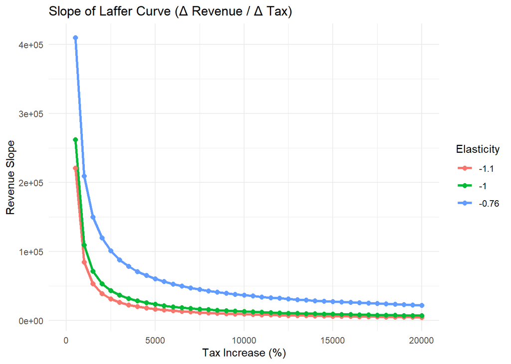

```r
laffer_slopes <- laffer_data %>%
  arrange(elasticity, tax_multiplier) %>%
  group_by(elasticity) %>%
  mutate(
    slope = c(NA, diff(total_revenue) / diff(tax_multiplier))
  ) %>%
  ungroup()

ggplot(laffer_slopes, aes(x = tax_multiplier * 100, y = slope, color = factor(elasticity))) +
  geom_line(size = 1.2) +
  geom_point(size = 2) +
  labs(
    title = "Slope of Laffer Curve (Δ Revenue / Δ Tax)",
    x = "Tax Increase (%)",
    y = "Revenue Slope",
    color = "Elasticity"
  ) +
  theme_minimal()
```

## References

Zabaloy, Maria Florencia, and Valentina Viego. 2022. “Household Electricity Demand in Latin America and the Caribbean: A Meta-Analysis of Price Elasticity.” *Utilities Policy* 75 (April): 101334. https://doi.org/10.1016/j.jup.2021.101334.